# Groundwater

Dr. Ahmad Redaa

2025-04-15

# Outlines

- Porosity and Permeability
- Groundwater Formations (Aquifer, Aquitard, Aquiclude, and Aquifuge)
- Groundwater Flow
- Groundwater Extraction
- Groundwater Contamination
- Groundwater Protection and Remediation

# Key Terms

- **Groundwater** is water stored in the open spaces (pores and fractures) within rocks and unconsolidated sediments below Earth’s surface.
- Near-surface materials are under lower pressure, allowing for more open space to store water.
- As a result, most groundwater accessed by individuals is within the **first 100 metres**.
- **Deeper groundwater** is used by some municipal, agricultural, and industrial users but is often of **lower quality** and **more costly** to extract.
- **Aquifer**: A layer of rock or sediment that stores and transmits groundwater.
- **Porosity**: The percentage of open space in a rock or sediment that can store water.
- **Permeability**: A measure of how easily water can flow through a material.
- **Water Table**: The top of the saturated zone where all pore spaces are filled with water.
- **Recharge**: The process of water entering and refilling an aquifer (e.g., from rain).
- **Discharge**: Groundwater leaving an aquifer, naturally (e.g., springs) or by pumping.
- **Capillary Action**: Water movement through narrow spaces due to adhesion and cohesion.
- **Fossil Water**: Ancient groundwater that has been trapped in an aquifer for thousands to millions of years.

# Groundwater

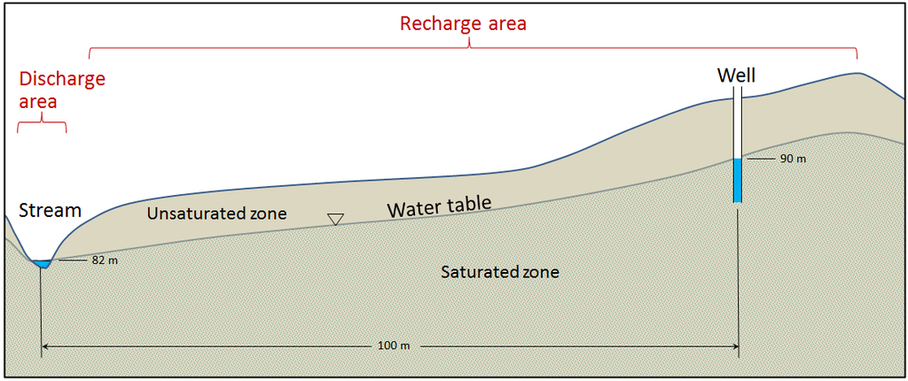

A depiction of the water table in cross-section, with the saturated zone below and the unsaturated zone above. Source: [Steven, E. (2015)](https://openlibrary-repo.ecampusontario.ca/jspui/handle/123456789/402)

# Porosity and Permeability

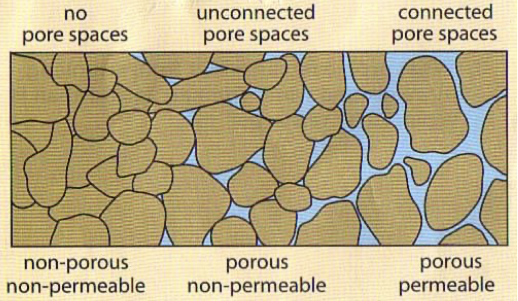

Source: [https://deq.louisiana.gov](https://deq.louisiana.gov/assets/docs/Water/DWPP_forkidsandeducators/PorosityandPermeability.pdf)

## Porosity

- **Porosity** is the percentage of total volume in a rock or sediment that consists of open (void) spaces.
- **Primary Porosity**: Original spaces between grains (common in sediments and sedimentary rocks).
- **Secondary Porosity**: Developed after rock formation (e.g., fractures, vesicles, solution cavities).

## Permeability

- **Permeability** is a measure of how easily water can flow through a rock or sediment.
- It depends on the size, shape, and connectivity of the pores.
- **Hydraulic Conductivity (K)** is used to quantify permeability (in metres/second).

# Differences Between Porosity and Permeability

| Feature | Porosity | Permeability |
| --- | --- | --- |
| Definition | Amount of void space in a material | Ability of fluid to flow through the material |
| Influencing factors | Grain size, sorting, cementation | Pore size, connectivity, tortuosity, pore shape |
| High Example | Silt and clay (porosity up to 70%) | Gravel, sand, fractured rocks |
| Low Example | Crystalline or compacted rocks | Clay, unfractured igneous/metamorphic rocks |

**Note**: A material like **clay** may have **high porosity** but **low permeability** due to small pore size and water binding to grain surfaces.

# Importance in Groundwater Storage and Movement

- **Porosity** controls how much water a rock or sediment can **store**.
- **Permeability** controls how easily water can **move** through it.
- **Aquifers**: Require **high porosity and high permeability** for effective water extraction.
- **Aquitards**: May store water but restrict its movement due to low permeability.
- Water moves from recharge to discharge zones, depending on **hydraulic gradient** and **permeability**.

# Groundwater Formations

- Aquifers
- Aquitards
- Aquicludes
- Aquifuges

# Aquifer

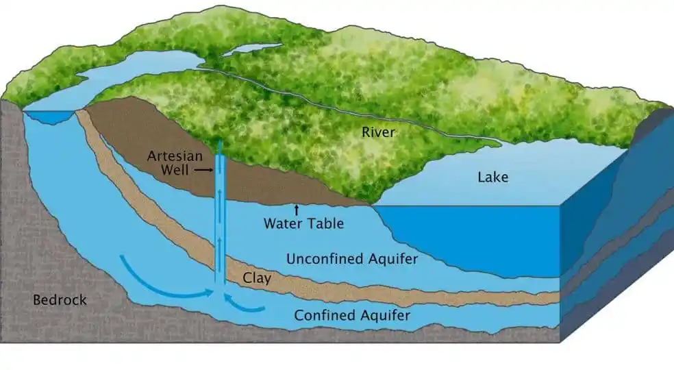

Source: [https://theconstructor.org](https://theconstructor.org/geotechnical/types-geological-formations-groundwater/34672/)

An **aquifer** is a saturated geological formation that **stores and yields groundwater** in usable quantities. Aquifers are **highly permeable**, allowing water to move easily through them.

## Types of Aquifers

- **Unconfined Aquifer**:
  - Has a free water surface (water table).
  - Open to direct recharge from rainfall or surface infiltration.
  - Also called water table aquifer or phreatic aquifer.
- **Confined Aquifer**:
  - Sandwiched between two **impermeable layers** (like clay or rock).
  - Water is under pressure and may rise in a well above the top of the aquifer (artesian conditions).
  - Recharge occurs where the aquifer is exposed at the surface.

**Examples**: Sand, gravel, sandstone, fractured limestone, fractured volcanic rocks

# Aquitard

- An **aquitard** is a **saturated but partially permeable** formation. It permits slow water movement but **does not yield water efficiently** like an aquifer.
- It can allow slow seepage of water into underlying aquifers.
- Typically composed of mixtures like **sandy clay**.

# Aquiclude

- An **aquiclude** is a geological formation that can **store water** but is **impermeable to flow**.
- High **porosity** but **very low or no permeability**.
- It contains water but does not allow it to pass through.
- **Example**: Clay

# Aquifuge

- An **aquifuge** is a **completely impermeable and non-porous** geological unit.
- **Cannot store or transmit water.**
- Acts as a barrier to groundwater flow.
- **Example**: Compact granite or dense crystalline rock

# Groundwater Formations Summary

| Formation | Water Storage | Permeability | Water Yield | Example |
| --- | --- | --- | --- | --- |
| **Aquifer** | High | High (permeable) | High | Sand, gravel |
| **Aquitard** | Moderate | Low (partly permeable) | Low (slow seepage) | Sandy clay |
| **Aquiclude** | High | Very low | None | Clay |
| **Aquifuge** | None | None | None | Compact granite |

- Understanding these formations helps hydrogeologists make decisions about:
  - Well locations
  - Sustainable water use
  - Groundwater contamination risks
  - Aquifer recharge zones

# Groundwater Flow

Groundwater does not flow like rivers underground — it moves **slowly through pore spaces and fractures** in soil and rock. Its movement is influenced by gravity and pressure differences, and it is governed by physical laws such as **Darcy’s Law**.

# The Water Table and Hydraulic Gradient

## Water Table

- The **water table** is the **top of the saturated zone** in an unconfined aquifer.
- It separates the **unsaturated zone** (air + water in pores) from the **saturated zone** (pores fully filled with water).
- The water table **rises and falls** with changes in recharge (rainfall) and usage (pumping).

## Hydraulic Gradient

- The **hydraulic gradient (i)** is the **slope of the water table** or potentiometric surface.
  - A **potentiometric surface** is the imaginary plane where a given reservoir of fluid will “equalize out to” if allowed to flow. A potentiometric surface is based on hydraulic principles. For example, two connected storage tanks with one full and one empty will gradually fill/drain to the same level [(Wikiowdia)](https://en.wikipedia.org/wiki/Potentiometric_surface).
- It drives groundwater flow from **high energy (high elevation or pressure)** to **low energy** zones.

$$i = \frac{{h_1 - h_2}}{{d}}$$

Where:  
- $h_1, h_2$: hydraulic head at two points  
- $d$: distance between the points

# Darcy’s Law and Groundwater Velocity

In 1856, Henri Darcy described groundwater flow mathematically:

## **Darcy’s Law**

$$Q = K \cdot A \cdot i$$

Where:  
- $Q$: volumetric flow rate (m³/s)  
- $K$: hydraulic conductivity (m/s)  
- $A$: cross-sectional area (m²)  
- $i$: hydraulic gradient (unitless)

## **Darcy Flux and Velocity**

- **Darcy Flux** (q): flow per unit area:
  $$q = K \cdot i$$
- **Actual groundwater velocity (v)**:
  $$v = \frac{q}{n}$$
  Where $n$ is **porosity** (as a decimal)

Groundwater velocity is usually **very slow** — often a few **cm/day** or less.

# Recharge and Discharge Areas

- **Recharge Area**: Region where water enters the groundwater system (e.g., rainfall infiltration).
- **Discharge Area**: Where groundwater flows out (e.g., springs, wetlands, streams).
- Water flows **from recharge to discharge areas**, following the hydraulic gradient.

# Groundwater Flow Paths and Equipotential Lines

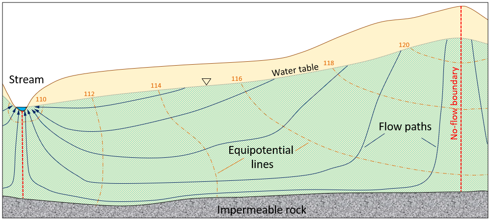

Source: [Steven, E. (2015)](https://openlibrary-repo.ecampusontario.ca/jspui/handle/123456789/402)

- Groundwater does **not flow in straight lines**.
- It follows **curved paths** from high-pressure (high head) to low-pressure zones.
- Flow is **perpendicular to equipotential lines** (lines of equal pressure).
- Near discharge zones, groundwater can **flow upward**.

**Key Concept**:  
- Groundwater flow resembles water flowing down a hill – it takes **twisting paths** through pores and fractures.  
- **No-flow boundaries** occur where pressure gradients are zero — water doesn’t move across these.

# Karst Systems and Groundwater in Caves

- Karst systems are formed in **soluble rocks** (e.g., limestone), creating:
  - Underground **caves**, **tunnels**, and **sinkholes** via dissolution.

## Two Zones in Karst:

- **Above the water table**:
  - Caves are air-filled.
  - Water moves quickly along cave floors under gravity.
- **Below the water table**:
  - Caves are water-filled.
  - Water behaves like normal groundwater, following **Darcy’s Law**.
- Karst aquifers often allow **rapid and unpredictable** groundwater movement — very different from typical porous media.

# Summary (Groundwater Flow)

| Concept | Description |
| --- | --- |
| Water Table | Top of the saturated zone |
| Hydraulic Gradient (i) | Slope driving groundwater flow |
| Darcy’s Law | Equation to calculate groundwater flow |
| Recharge Area | Where water enters the groundwater system |
| Discharge Area | Where groundwater exits to surface |
| Flow Paths & Equipotentials | Water flows from high to low head, curved paths |
| Karst Systems | Unique rapid groundwater flow in limestone caves |

# Groundwater Extraction and Monitoring

- To use groundwater as a water resource, we must extract it through **wells**. This process involves careful planning, drilling, and monitoring to ensure **sustainable use** and avoid problems like over-pumping or water table decline.

# Well Drilling, Construction, and Pumping

- A **well** is a vertical shaft drilled into the ground to access groundwater in an aquifer.
- **Shallow wells** may be hand-dug or drilled; **deep wells** require mechanical rigs.
- Wells must reach below the **water table** to access water reliably.
- A **well casing** (usually steel or plastic) is installed to support the well walls and prevent collapse.
- A **well screen** is fitted at the bottom to allow water in but keep sediment out.
- Water is lifted using **submersible pumps** or air-lift systems.
- Well depth and construction depend on aquifer type and water demand.

# Cones of Depression and Over-Pumping

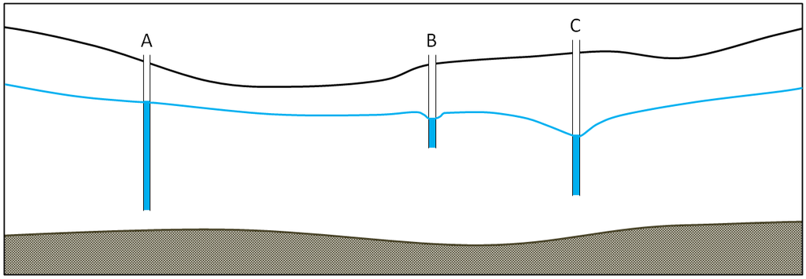

Three wells in an unconfined aquifer. Well A is not being pumped. Well B is being pumped at a slow rate and well C, which has a larger cone of depression, is being pumped at a faster rate. Source: [Steven, E. (2015)](https://openlibrary-repo.ecampusontario.ca/jspui/handle/123456789/402)

- When a well is pumped, it draws water from the surrounding aquifer.
- This causes the **water table (or potentiometric surface)** to dip toward the well, forming a **cone of depression**.

## Impacts of Over-Pumping:

- **Drying nearby wells** (if cones of depression overlap).
- **Land subsidence** (especially in clay-rich areas).
- **Reduction of baseflow** to streams and ecosystems.
- **Saltwater intrusion** in coastal areas.

# Observation Wells and Groundwater Monitoring

- **Observation wells** are **non-pumping wells** installed to monitor:
  - **Water table levels**
  - **Aquifer pressure**
  - **Water quality**
- Many observation wells are equipped with **automated sensors** for real-time data.
- Governments and agencies use these wells to detect **trends** and **overuse**.

## Example:

- British Columbia has 145+ active observation wells.
- Data is available publicly to track seasonal and long-term changes.

# Seasonal and Long-Term Changes in Groundwater Levels

## Seasonal Changes:

- Water levels drop during **dry seasons** (e.g., summer).
- Water levels rise during **wet seasons** (e.g., winter), as recharge increases.

## Long-Term Trends:

- May show:
  - **Decline** due to over-pumping or drought.
  - **Stability** in balanced systems.
  - **Recovery** after conservation efforts.
- Observation wells help distinguish **natural variation** from **human impacts**.

# Summary (Groundwater Extraction and Monitoring)

| **Topic** | **Key Points** |
| --- | --- |
| Well Construction | Requires casing, screen, and proper depth for reliability |
| Pumping Effects | Causes cone of depression, may dry nearby wells |
| Over-Pumping Risks | Can lead to land subsidence, stream drying, saltwater intrusion |
| Observation Wells | Monitor water levels and quality without extracting water |
| Seasonal Variations | Water levels drop in dry seasons, rise in wet seasons |
| Long-Term Changes | Reflect climate trends or usage practices |

# Groundwater Contamination: Sources and Impacts

Although groundwater is often considered a clean and protected water source, it is **vulnerable to contamination** from both natural and human-made sources. Contamination can make water unsafe for **drinking**, **irrigation**, and **ecosystems**, and it is **difficult and costly to clean** once it occurs.

# Natural Contamination

Some groundwater becomes contaminated **naturally** due to interaction with rocks and minerals in the aquifer.

## Common Natural Contaminants:

- **Fluorine**:
  - Found in rocks like volcanic ash or clays.
  - In high concentrations, causes **fluorosis** (dental and skeletal).
  - Example: Nanaimo Group aquifers (B.C.) with high-pH water mobilizing fluorine.
- **Arsenic**:
  - Occurs in sediments under **anoxic conditions** (low oxygen).
  - Found in **Bangladesh delta aquifers**; linked to serious health problems (cancer, organ damage).
  - Solubility increases in **reducing environments**.

# Anthropogenic (Human-Made) Contamination

Human activities at the surface (or underground) are a **major source of groundwater pollution**. Some sources release pollutants slowly over time, while others are caused by accidental spills or leaks.

## A. Agriculture

- Use of **fertilizers** and **manure** adds **nitrates** to the soil.
- Excess nitrates can leach into shallow aquifers, especially in **sandy soils**.
- **Nitrate-contaminated groundwater** poses health risks (e.g., “blue baby syndrome” in infants).
- **Example**: Abbotsford-Sumas aquifer (B.C.)—nitrate levels exceeded safe drinking limits due to poultry farming and berry crops.

## B. Landfills and Leachate

- **Old dumpsites** lacked protective liners; rainwater infiltrated and formed **leachate**.
- **Leachate** contains chemicals, metals, and organics that may reach the aquifer.
- Modern landfills use:
  - **Plastic or clay liners**
  - **Leachate collection systems**
  - **Monitoring wells**

## C. Industrial Pollution

- Factories and smelters may release **toxic substances** (e.g., lead, zinc, solvents).
- Pollutants can leach into soil and groundwater.
- **Example**: Trail, B.C.—lead and zinc smelter contaminated soils and groundwater.

## D. Mines and Acid Rock Drainage (ARD)

- Exposure of **sulfide-rich rocks** (e.g., pyrite) to air and water leads to formation of **acidic water**.
- ARD increases **metal solubility**, polluting streams and groundwater.
- **Example**: Mt. Washington Mine (Vancouver Island) — ARD with toxic copper runoff.

## E. Leaking Underground Storage Tanks (USTs)

- **Gas stations** and industrial sites use buried tanks for fuel.
- Over time, tanks **corrode and leak**, contaminating groundwater with:
  - **Petroleum hydrocarbons**
  - **Volatile organic compounds (VOCs)**
- Leaked fuel may:
  - Float on water table
  - Dissolve and spread
  - Vaporize and migrate toward surface

## F. Septic Systems

- Common in rural areas without sewage networks.
- If not maintained properly, they can:
  - Leak untreated sewage into the soil
  - Contaminate shallow groundwater with **bacteria, nitrates, and chemicals**

### Causes of Septic Failure:

- Overflow from lack of pumping
- Cracked or old tanks
- Poor soil drainage or high water tables

# Summary Table of Contamination Sources

| **Source** | **Contaminants** | **Risk Level** | **Example** |
| --- | --- | --- | --- |
| Fluorine (natural) | Fluoride ions | Moderate–High | Nanaimo Group (B.C.) |
| Arsenic (natural) | Arsenic | High | Bangladesh delta aquifers |
| Agriculture | Nitrates | High | Abbotsford-Sumas (B.C.) |
| Landfills | Leachate (mixed chemicals) | High | Improperly lined landfills |
| Industrial Sites | Heavy metals, solvents | High | Trail lead-zinc smelter |
| Mines (ARD) | Acidic water, heavy metals | High | Mt. Washington Mine |
| Leaking Fuel Tanks (USTs) | Petroleum, VOCs | High | Abandoned gas station sites |
| Septic Systems | Bacteria, nitrates | Moderate | Rural residential areas |

## Notes

- **Prevention is better than cleanup** — most contaminated groundwater is extremely difficult to restore.
- Solutions include:
  - Better land-use planning
  - Monitoring networks
  - Engineering controls (liners, caps, well design)
  - Groundwater modeling and risk mapping

# Groundwater Protection and Remediation

Groundwater is a **critical natural resource** that is difficult to clean once contaminated. Protecting groundwater from pollution and applying effective **remediation strategies** are key parts of environmental and water resource management.

# Preventing Groundwater Contamination

## A. Physical Barriers

### 1. **Caps and Covers**

- Used to prevent **rainwater infiltration** that could carry pollutants into the subsurface.
- Common in:
  - Landfills
  - Mine tailings
  - Contaminated industrial sites

### 2. **Liners**

- **Impermeable barriers** (plastic or engineered clay) placed **beneath** landfills or tailings ponds.
- Prevent contaminated water (leachate) from seeping downward into aquifers.

> Caps = Stop water from entering.  
> Liners = Stop water from escaping downward.

## B. Land Use and Zoning Controls

- Restricting hazardous activities above vulnerable aquifers
- Requiring buffer zones around wells and recharge areas

# Groundwater Remediation Strategies

Once contamination has occurred, **remediation** is often necessary. These techniques aim to stop further spread and to clean up existing pollution.

## A. **Pump-and-Treat**

- Contaminated groundwater is **pumped to the surface**, treated, and **discharged or reinjected**.
- Common for:
  - Petroleum hydrocarbons
  - Metals
  - Industrial solvents

## B. **Containment**

- Involves **hydraulic control** using wells or physical barriers.
- Goal: prevent plume from migrating toward sensitive areas (e.g., streams, drinking wells).

## C. **Manipulating Groundwater Flow**

- Strategic pumping from nearby wells can redirect flow **away** from vulnerable targets.
- Injection wells can also be used to **create a hydraulic barrier**.

> These methods are expensive and slow — prevention is always preferred.

# Monitoring and Groundwater Legislation

## A. **Monitoring Wells**

# Summary Table (Groundwater Protection and Remediation)

| **Topic** | **Key Points** |
| --- | --- |
| Caps and Liners | Prevent surface contaminants from reaching aquifers |
| Pump-and-Treat | Remove and treat groundwater at surface |
| Containment Strategies | Prevent spread of contamination using barriers and hydraulic control |
| Monitoring Wells | Track groundwater levels and pollution |
| Water Sustainability Act | Requires extraction licenses, supports environmental protections |

# Final Thought

Groundwater is **invisible but essential** — it supports drinking water, farming, and ecosystems. Protecting it requires **planning, policy, and technology**, and understanding **hydrogeological principles** is the first step.